# Week 12: Kernels and Gaussian Processes

PS 818 - Data Analysis with Statistical Models

Anton Strezhnev

strezhnev@wisc.edu

University of Wisconsin-Madison

November 23, 2026

## Kernels and Gaussian Processes

## Previously

- **Trees**
  - Recursive partitioning: split the predictors into rectangles and predict a constant in each
  - Interpretable, but high variance
- **Ensembles of trees**
  - **Averages** of deep trees: bagging and random forests
  - **Sums** of small trees: boosting and BART

## This week

- **Kernel methods**
  - Kernels as regression inputs: searching over a (possibly infinite-dimensional) space of functions
  - **Kernel regularized least squares**: ridge regression on a kernel matrix
- **Gaussian processes**
  - The Bayesian interpretation of KRLS
  - A prior over **functions**

## Going forward

- **Week 13** - Causal Inference with Flexible Regression
- **Week 14** - Working with “Big” Datasets

## Example: Interpolating spatial data

- A very common problem in spatial statistics is predicting an outcome at any given latitude/longitude coordinate given a finite set of observations at particular coordinates
  - e.g. What is the estimated average temperature given observations at a number of weather monitoring stations?
  - Finding the “best” interpolation between the observed points is known as “kriging” in the geostatistics literature
- We’ll use a sample of U.S. weather stations as an example:

```r
library(sf)
```

## Example: Interpolating spatial data

- Start by reading in the U.S. shapefile

```r
us_shapefile <- read_rds("data/us_shapefile.rds") %>%
  filter(!(STUSPS %in% c("AK", "HI", "AS", "GU", "MP", "PR", "VI")))
```

- Next, read in the NOAA Climate Assessment Database monthly weather station data from January, 2025.
  - `atmp` is the station’s average temperature for the month and `ntmp` its “normal” temperature for January (both in degrees C)

```r
weather <- read_csv("data/monthly_summary_202501_v2.csv") %>% filter(country == "UNITED_STATES")
weather <- weather %>% filter(atmp > -99999&ntmp > -99999) # Missing obs hard coded as -99999
weather <- weather %>% mutate(deviation = atmp - ntmp)
weather <- weather %>% filter(!(state %in% c("AK", "HI", "AS", "GU", "MP", "UM", "PR", "VI")))
```

## Example: Interpolating spatial data

- Convert to a plottable object and overlay on the map

```r
# Convert the stations to a plottable object
weather_sf <- st_as_sf(weather, coords = c("lon", "lat"), crs = st_crs(us_shapefile), remove=F)
```

## Example: Interpolating spatial data

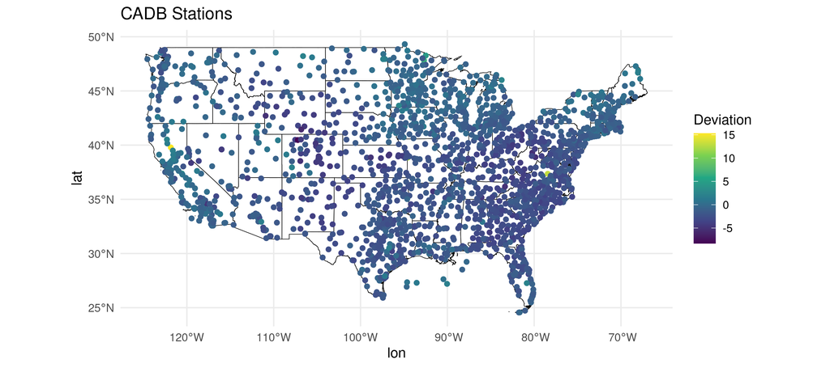

## Example: Interpolating spatial data

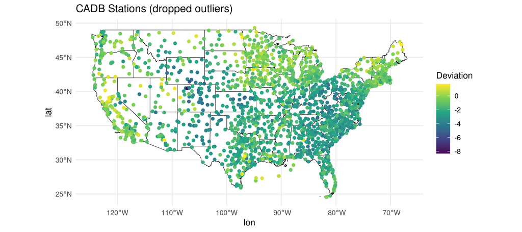

## Example: Interpolating spatial data

- We’ll make a grid of 50km squares on which to evaluate our predictions

```r
# Set boundaries for U.S. (approximate)
lat_min <- 24.396308  # Southernmost point (Florida)
lat_max <- 49.384358  # Northernmost point (Canada border)
lon_min <- -125.0     # Westernmost point (California)
lon_max <- -66.93457  # Easternmost point (Maine)

# Approximate 50 km in degrees (this will vary by latitude, but we'll use an average factor)
lat_interval <- 50 / 110.574  # 1 degree latitude ≈ 110.574 km
lon_interval <- 50 / (111.320 * cos(mean(c(lat_min, lat_max)) * pi / 180))  # Longitude interval varies with latitude

# Create a sequence of points for latitude and longitude
latitudes <- seq(lat_min, lat_max, by = lat_interval)
longitudes <- seq(lon_min, lon_max, by = lon_interval)

# Create a grid of all combinations of latitudes and longitudes
grid_points <- expand.grid(lat = latitudes, lon = longitudes)

# Convert the grid points to an 'sf' object
grid_points_sf <- st_as_sf(grid_points, coords = c("lon", "lat"), crs = st_crs(us_shapefile), remove=F)

# Filter grid points to keep only those within the U.S. boundary
grid_points_within_us <- st_intersection(grid_points_sf, us_shapefile)
```

## Example: Interpolating spatial data

- A linear regression on latitude, longitude, and their interaction seems to miss a lot of the geographic nuances.

```r
weather_linear <- lm(deviation ~ lat + lon + lat*lon, data=weather)
grid_points_within_us$linpredict <- predict(weather_linear, newdata=grid_points_within_us)
```

## Example: Interpolating spatial data

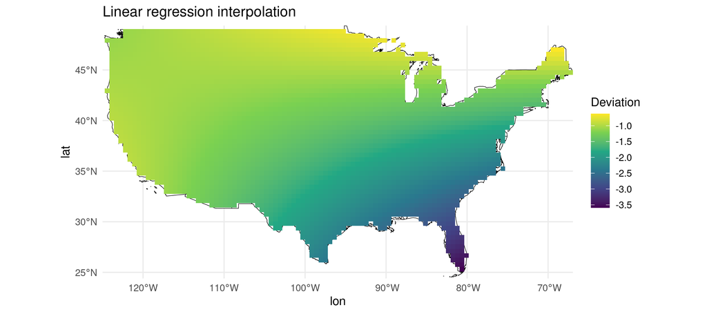

## Optimization over functions

- At the most general level, (nearly) every method we’ve talked about involves finding a **function** that optimizes some **objective**
- Given a set of $n$ inputs, $\{x_i, y_i\}$, we want to find a function that solves

  $$\hat{f} = \argmin_{f} \ \mathcal{L}\bigg(f, \{x_i, y_i\}_{i=1}^n\bigg)$$

We started with some **severe** constraints on the space of functions over which we search.

- **Linear functions**

  $$f(x) = \beta_0 + \beta_1x_1 + \beta_2x_2 + \beta_3x_3 + \dotsc$$

## Space of functions

- We’ve considered relaxations that allow our functions to be more **flexible** in form
- **Basis expansions**

  $$f(X) = \sum_{m=1}^M \beta_m h_m(X)$$
- **Penalized** basis expansions (e.g. smoothing splines)

  $$\min_f \sum_{i=1}^N \big(Y_i - f(X_i)\big)^2 + \lambda \int f''(x)^2 \, dx$$

## Space of functions

- **Trees** are are also a kind of basis expansion with an adaptively chosen basis: $h_m(x) = \mathbf{1}(x \in R_m)$

  $$g(x; T, M) = \sum_{m=1}^{|T|} \mu_m \mathbf{1}(x \in R_m)$$
- **Ensembles** of trees

  $$f(x) = \sum_{b=1}^B w_b \, g(x; T_b, M_b)$$

## Forests as weighted averages

- One can think of a forest as also a kind of **weighted average** prediction using “similar” observations (Athey, Tibshirani, and Wager 2019)

  $$\hat{f}(x) = \sum_{i=1}^N \alpha_i(x) Y_i, \quad \alpha_i(x) = \frac{1}{B} \sum_{b=1}^B \frac{\mathbf{1}\big(X_i \in L_b(x)\big)}{|L_b(x)|}$$
  - $L_b(x)$ is the set of tree $b$’s training observations that share a leaf with $x$.
  - $\alpha_i(x)$ measures how **similar** $X_i$ is to $x$
- Can we be more flexible than this while still retaining computational feasibility?

## Space of functions defined by kernels

- “Kernel methods” consider searching over a space of functions defined implicitly by a positive-definite kernel function.
  - Example, the **Gaussian** kernel

    $$K(x, x^\prime) = \exp\bigg(-\frac{||x - x^\prime||^2}{2\sigma^2}\bigg)$$
- The set of functions we’ll search over is a **linear combination** of kernels evaluated at the data points.

  $$f(x) = \sum_{i=1}^N c_i K(x, x_i)$$
- What is this space of functions? How “flexible” is it?

## Intuition from ridge regression

- Take any basis expansion $\phi(x) = \big(h_1(x), \dotsc, h_M(x)\big)$, possibly with **more** features than observations ($M > N$). Row $i$ of $\Phi$ is $\phi(x_i)^\prime$.

  $$\hat{\beta} = \argmin_{\beta} \ (\mathbf{y} - \Phi\beta)^\prime(\mathbf{y} - \Phi\beta) + \lambda \beta^\prime\beta$$
- Split any $\beta$ into a combination of the data points plus a leftover $r$ that is orthogonal to every $\phi(x_i)$

  $$\beta = \sum_{i=1}^N c_i \phi(x_i) + r$$
  - The leftover doesn’t change any fitted value: $\phi(x_i)^\prime r = 0$
  - But it adds to the penalty: $\beta^\prime\beta = \big|\big|\sum_i c_i\phi(x_i)\big|\big|^2 + r^\prime r$
- So ridge always sets $r = 0$. The solution is always a combination of the **data points**: $\hat{\beta} = \sum_{i=1}^N \hat{c}_i \phi(x_i)$

## The representer theorem

- The prediction at any $x$ only needs **inner products** between $\phi(x)$ and the data

  $$\hat{f}(x) = \phi(x)^\prime\hat{\beta} = \sum_{i=1}^N \hat{c}_i \, \phi(x)^\prime\phi(x_i) = \sum_{i=1}^N \hat{c}_i K(x, x_i)$$
- So do the fit and the penalty. With $\mathbf{K} = \Phi\Phi^\prime$ we get $\Phi\beta = \mathbf{K}\mathbf{c}$ and $\beta^\prime\beta = \mathbf{c}^\prime\mathbf{K}\mathbf{c}$
- **The kernel trick**: we never need $\phi$ itself, only $K(x, x^\prime) = \phi(x)^\prime\phi(x^\prime)$
  - The Gaussian kernel corresponds to **infinitely** many features. We could never run that regression, but the $N \times N$ problem in $\mathbf{c}$ is just as easy.
- **Representer theorem**: this works for any loss function. The penalized solution is always a weighted sum of $N$ kernels, one centered at each data point.
  - The space of functions built this way, with $\mathbf{c}^\prime\mathbf{K}\mathbf{c}$ as its “size”, is called a **reproducing kernel Hilbert space** (RKHS)

## Kernel Regularized Least Squares

- Intuitively, what the “kernel trick” allows us to do is design a good functional approximator by way of a conventional ridge regression estimator.
  - Relatively well-known in machine learning (particularly for classification) throughout the 2000s, but introduced to political science by Hainmueller and Hazlett (2014) and labeled **Kernel regularized least squares**
- Our regression matrix is constructed by creating a total of $N$ columns.
  - Column $j$ is the kernel evaluated between each observation and $x_j$, so the prediction for $x_i$ is a linear combination of the kernels in row $i$

    $$f(x_i) = c_1K(x_i, x_1) + c_2K(x_i, x_2) + \dotsc c_n K(x_i, x_n)$$
- The regression matrix $\mathbf{K}$ is $N \times N$
  - We need to regularize!

## Kernel Regularized Least Squares

- For $f(x) = \sum_{i=1}^n c_i K(x, x_i)$, the RKHS norm is $||f||^2_{\mathcal{H}_K} = \mathbf{c}^\prime\mathbf{K}\mathbf{c}$
- So KRLS is a **ridge regression** of $\mathbf{y}$ on the columns of $\mathbf{K}$, with a penalty that also uses $\mathbf{K}$

  $$\hat{\mathbf{c}} = \argmin_{\mathbf{c}} \ (\mathbf{y} - \mathbf{K}\mathbf{c})^\prime(\mathbf{y} - \mathbf{K}\mathbf{c}) + \lambda \mathbf{c}^\prime\mathbf{K}\mathbf{c}$$
- With a closed-form solution

  $$\hat{\mathbf{c}} = (\mathbf{K} + \lambda \mathbf{I})^{-1}\mathbf{y}$$
- Two tuning parameters: the kernel **bandwidth** $\sigma^2$ and the **penalty** $\lambda$

## Kernel Regularized Least Squares

- What happens when we fit KRLS with latitude and longitude as the covariate inputs.

```r
library(KRLS)
```

- Estimate the model
  - `krls()` standardizes each input and uses the kernel $\exp(-||x - x^\prime||^2/\sigma^2)$. Its argument `sigma` is the $\sigma^2$ in that formula.
  - We use the Hainmueller and Hazlett (2014) approach of setting $\sigma^2$ equal to the number of dimensions in the data (here, 2).
  - $\lambda$ is chosen by minimizing the leave-one-out error, which has a nice closed form.
  - `approx = "none"`: since version 1.7, `krls()` silently switches to a low-rank approximation of $\mathbf{K}$ when $N > 500$.

```r
krls_reg <- krls(X = model.matrix(~lat + lon, data=weather)[,-1],
                 y = weather$deviation,
                 whichkernel = "gaussian",
                 sigma = 2,
                 approx = "none",
                 vcov=F,
                 derivative=F)
```

## Kernel Regularized Least Squares

- What do the inputs look like?

```r
dim(krls_reg$K)
```

```
[1] 1825 1825
```

```r
head(krls_reg$K[,1])
```

```
       1        2        3        4        5        6
1.00e+00 6.90e-07 1.38e-06 2.62e-06 8.33e-06 1.22e-05
```

```r
head(krls_reg$K[,2])
```

```
       1        2        3        4        5        6
6.90e-07 1.00e+00 9.69e-01 9.17e-01 8.01e-01 7.69e-01
```

```r
head(krls_reg$K[,3])
```

```
       1        2        3        4        5        6
1.38e-06 9.69e-01 1.00e+00 9.86e-01 9.11e-01 8.83e-01
```

## Kernel Regularized Least Squares

- What do the inputs look like?

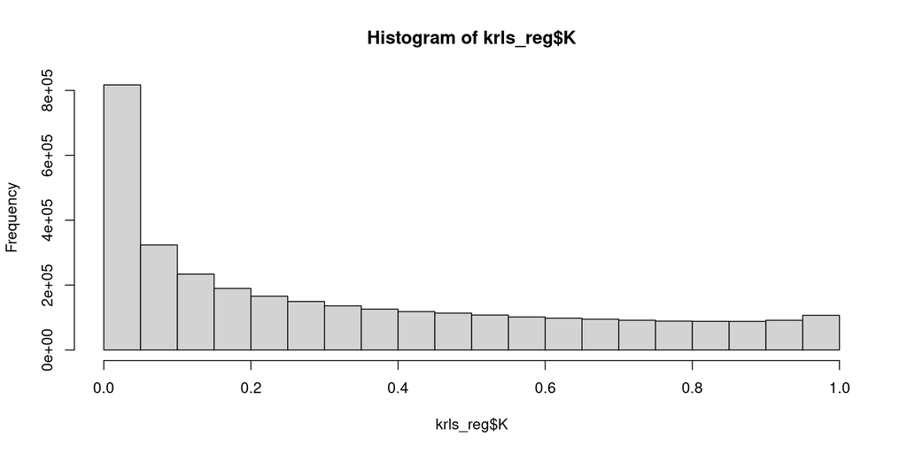

```r
hist(krls_reg$K)
```

## Kernel Regularized Least Squares

- Predict using the KRLS regression for each of our grid squares.

```r
grid_points_within_us$krlspredict <- predict(krls_reg, newdata= model.matrix(~lat + lon, data=grid_points_within_us)[,-1])$fit
```

## Kernel Regularized Least Squares

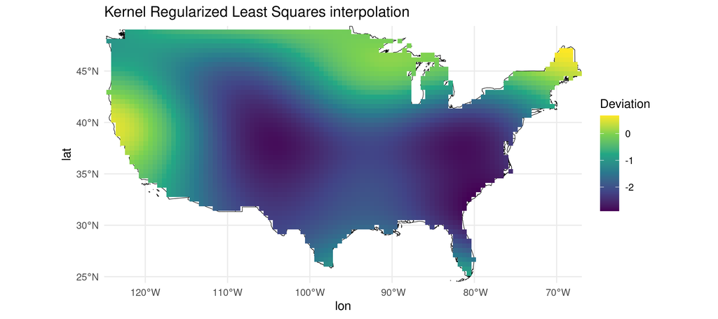

## Kernel Regularized Least Squares

- What if we chose a smaller bandwidth for the Gaussian kernel?

```r
krls_reg_2 <- krls(X = model.matrix(~lat + lon, data=weather)[,-1],
                 y = weather$deviation,
                 sigma = 1/5,
                 whichkernel = "gaussian",
                 approx = "none",
                 vcov=F,
                 derivative=F)
```

## Kernel Regularized Least Squares

- Predict using the KRLS regression for each of our grid squares.

```r
grid_points_within_us$krlspredict2 <- predict(krls_reg_2, newdata= model.matrix(~lat + lon, data=grid_points_within_us)[,-1])$fit
```

## Kernel Regularized Least Squares

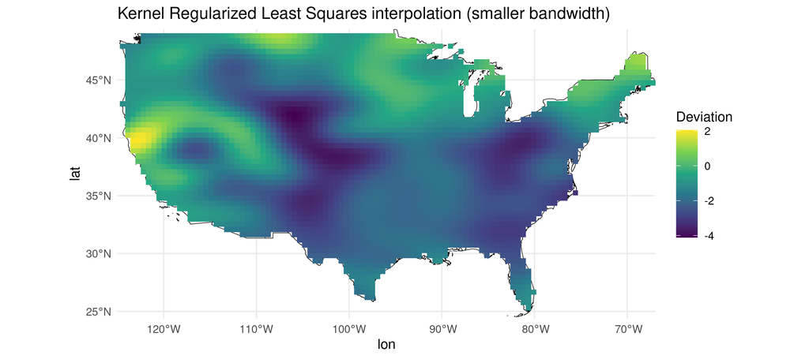

## Gaussian processes: KRLS, but Bayes

- Ridge regression is the posterior mode under a **normal prior** on $\beta$. KRLS has the same Bayesian reading.
- **Prior**: the function values at the data are multivariate normal, with the **kernel** as their covariance

## What we get from Bayes

- **Uncertainty**: the full posterior of $f(x^*)$ is normal, with variance

  $$Var[f(x^*)|\mathbf{y}] = K(x^*, x^*) - \mathbf{k}_*(\mathbf{K} + \sigma_y^2 I)^{-1}\mathbf{k}_*^\prime$$

## GPs for geostatistics

- “kriging” in geostatistics **is** gaussian process regression
- Same Gaussian kernel as before, but with the inputs in **kilometers** (a flat map projection) instead of standardized latitude and longitude
  - Previously, we standardized latitude and longitude separately, so a north-south kilometer counted about twice as much as an east-west one (b/c of the shape of the continental U.S.).

```r
stations_km <- st_coordinates(st_transform(weather_sf, 5070)) / 1000 # EPSG 5070: Albers projection, in meters
grid_km <- st_coordinates(st_transform(grid_points_within_us, 5070)) / 1000
```

- Write our kernel function

```r
rbf_kernel <- function(x, xprime, sigma0, l) { # matrix of K(x_i, xprime_j), one row per point
  x <- as.matrix(x); xprime <- as.matrix(xprime)
  sq_dist <- outer(rowSums(x^2), rowSums(xprime^2), "+") - 2 * tcrossprod(x, xprime)
  sigma0^2 * exp(-pmax(sq_dist, 0) / (2 * l^2))
}
```

## Kriging: choosing the hyperparameters

- “Empirical Bayes” - maximize the marginal likelihood $\mathbf{y} \sim \text{Normal}(\boldsymbol{\mu}, \mathbf{K} + \sigma_y^2 I)$

```r
gp_neg_loglik <- function(log_par, x, y) { # log_par = log(sigma0, l, sigma_y)
  par <- exp(log_par)
  Sigma <- rbf_kernel(x, x, par[1], par[2]) + diag(par[3]^2, length(y))
  -mvtnorm::dmvnorm(y, rep(mean(y), length(y)), Sigma, log = TRUE)
}
krig_opt <- optim(log(c(3, 300, 1)), gp_neg_loglik, x = stations_km, y = weather$deviation)
krig_par <- setNames(exp(krig_opt$par), c("sigma0", "l", "sigma_y"))
krig_par
```

```
 sigma0       l sigma_y
   1.04  186.37    1.03
```

- A smooth surface with an SD of about 1.0°C that varies over roughly 190 km, plus 1.0°C of station-level noise

## Kriging: the posterior

```r
gp_predict <- function(x, y, x_new, sigma0, l, sigma_y) { # posterior mean and SD of f(x_new)
  K_inv <- solve(rbf_kernel(x, x, sigma0, l) + diag(sigma_y^2, length(y)))
  k_star <- rbf_kernel(x_new, x, sigma0, l)
  post_mean <- as.vector(mean(y) + k_star %*% K_inv %*% (y - mean(y)))
  post_sd <- sqrt(pmax(sigma0^2 - rowSums((k_star %*% K_inv) * k_star), 0))
  data.frame(fit = post_mean, sd = post_sd, lower = post_mean - 1.96 * post_sd, upper = post_mean + 1.96 * post_sd)
}
krig <- gp_predict(stations_km, weather$deviation, grid_km, krig_par["sigma0"], krig_par["l"], krig_par["sigma_y"])
grid_points_within_us$gp_mean <- krig$fit
grid_points_within_us$gp_sd <- krig$sd
```

## Kriging: posterior mean

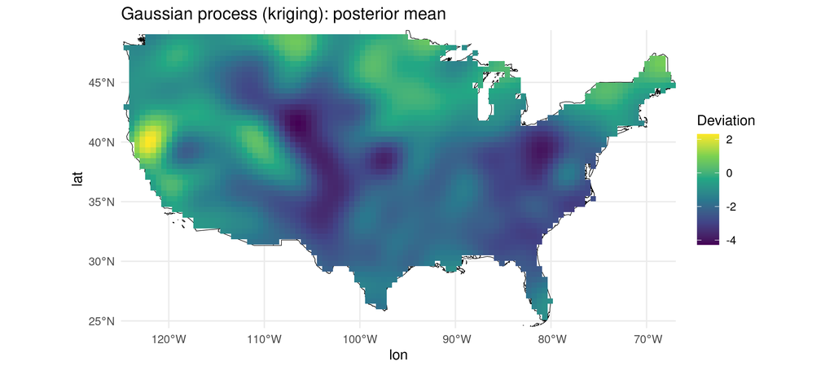

## Kriging: posterior SD

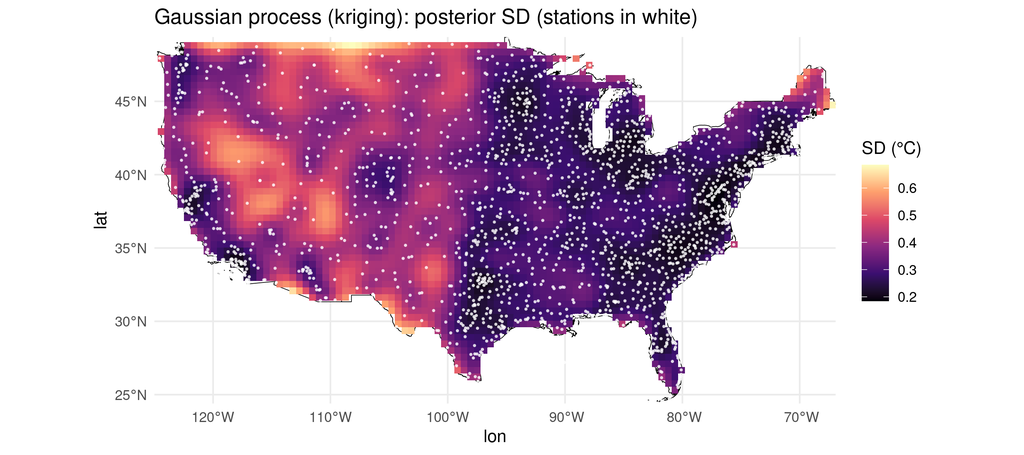

- Most certain where stations are dense (the East), least certain in the sparse interior West and along the edges of the map

## Example: Poll averaging

- GPs are also a natural tool for smoothing a **time series**
  - All 191 national polls of the 2012 presidential race, from April through Election Day

```r
polls_all <- read_csv("data/all_polls_2012.csv") %>% filter(state == "--") %>% # national polls
  mutate(end.date = mdy(end.date),
         obama.2way = obama/(obama + romney),
         day = as.numeric(end.date - ymd("2012-11-06"))) # 0 = Election Day, -211 = April 9
actual_2way <- 65915795/(65915795 + 60933504) # Obama's share of the two-party vote (FEC)
```

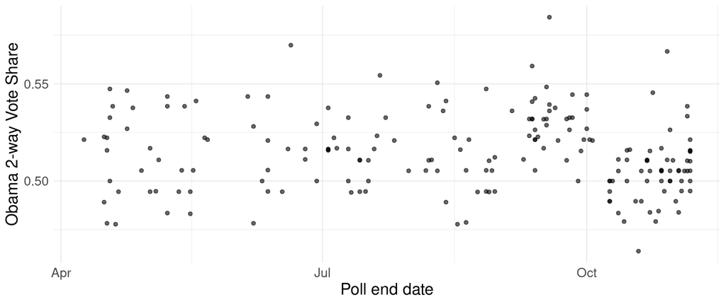

## Draws from the prior

- What trends does the prior consider plausible?
  - Consider a prior standard deviation of $\sigma_0 = 0.02$ (2 percentage points) and a length-scale of $l = 14$ days

```r
set.seed(53703)
sample_days <- seq(-215, 0, by = 1)
prior_draws <- MASS::mvrnorm(n = 2, mu = rep(mean(polls_all$obama.2way), length(sample_days)),
                             Sigma = rbf_kernel(sample_days, sample_days, sigma0 = .02, l = 14))
```

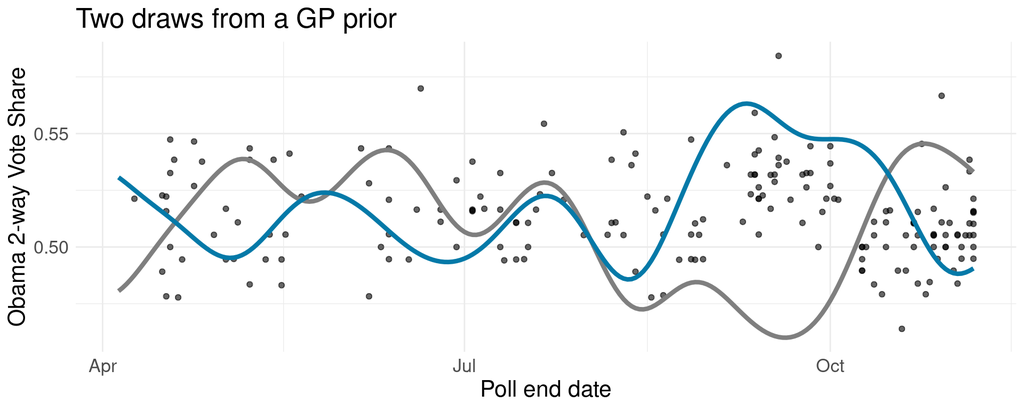

- “Close” days have similar values of $f$. The length-scale $l$ controls what “closeness” means.

## Smoothing the whole campaign

- We’ll use an **empirical bayes** approach to choosing the hyperparameters again: $\sigma_0$, $l$ and $\sigma_y$ selected by maximizing the marginal likelihood

```r
gp_opt_all <- optim(log(c(.02, 14, .02)), gp_neg_loglik, x = polls_all$day, y = polls_all$obama.2way)
gp_par_all <- setNames(exp(gp_opt_all$par), c("sigma0", "l", "sigma_y"))
gp_par_all
```

```
  sigma0        l  sigma_y
 0.00769 10.56362  0.01799
```

```r
days_all <- seq(-215, 0, by = .5)
gp_all <- data.frame(day = days_all, gp_predict(polls_all$day, polls_all$obama.2way, days_all,
                                                gp_par_all["sigma0"], gp_par_all["l"], gp_par_all["sigma_y"])) %>%
  rename(obama.2way = fit)
```

- A length-scale of about 11 days
- The trend moves by about 0.8 points, and the polls scatter around it by about 1.8 - most poll-to-poll movement is **noise**.
  - That’s somewhat more than sampling error alone (about 1.5 points for these polls)

## Smoothing the whole campaign

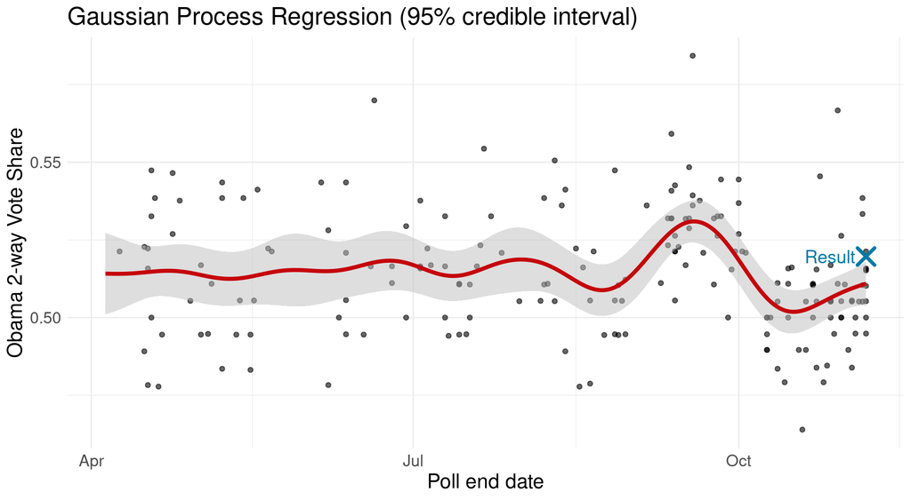

## Election Day

- The GP’s estimate of the poll average on Election Day: 51.1% (95% interval: 50.4% to 51.8%)
  - Obama’s actual two-party vote share: 52.0%
- Election Day is the **end** of the series:
  - Far from the data, the GP’s mean reverts to the prior mean $\mu$ w/ a wider interval.
  - For **forecasting**, it matters how we *extrapolate* from the data.

## Random walks are GPs too

- Poll aggregators usually model the trend as a **random walk** (Jackman 2005; Linzer 2013)

  $$f(t) = f(t-1) + \epsilon_t$$
- That’s just a GP with a different kernel:
  - Random walk (Brownian motion): $K(s, t) = \sigma_0^2\min(s, t)$
  - AR(1): $K(s, t) = \sigma_0^2\exp(-|s - t|/l)$
- These kernels are **Markov**: the future depends on the past only through the present.
  - Methods developed from the time series literature typically much faster (no need to invert an N x N matrix!) - e.g. **Kalman Filtering**
- After the last poll, a random walk keeps the **last level** instead of reverting to the grand mean.

## Next week

- **Causal inference with flexible regression**
  - Efficient semiparametric estimation of statistical functionals
  - Influence functions
  - “Doubly-robust”/“Neyman-orthogonal” estimators
- **Readings**: Fisher and Kennedy (2021); Kennedy (2024)

## References

Athey, Susan, Julie Tibshirani, and Stefan Wager. 2019. “Generalized Random Forests.” *The Annals of Statistics* 47 (2): 1148–78. https://doi.org/10.1214/18-AOS1709.

Fisher, Aaron, and Edward H. Kennedy. 2021. “Visually Communicating and Teaching Intuition for Influence Functions.” *The American Statistician* 75 (2): 162–72. https://doi.org/10.1080/00031305.2020.1717620.

Hainmueller, Jens, and Chad Hazlett. 2014. “Kernel Regularized Least Squares: Reducing Misspecification Bias with a Flexible and Interpretable Machine Learning Approach.” *Political Analysis* 22 (2): 143–68. https://doi.org/10.1093/pan/mpt019.

Jackman, Simon. 2005. “Pooling the Polls over an Election Campaign.” *Australian Journal of Political Science* 40 (4): 499–517. https://doi.org/10.1080/10361140500302472.

Kennedy, Edward H. 2024. “Semiparametric Doubly Robust Targeted Double Machine Learning: A Review.” In *Handbook of Statistical Methods for Precision Medicine*, 207–36. https://arxiv.org/abs/2203.06469.

Linzer, Drew A. 2013. “Dynamic Bayesian Forecasting of Presidential Elections in the States.” *Journal of the American Statistical Association* 108 (501): 124–34. https://doi.org/10.1080/01621459.2012.737735.